# Project Fundations of Statistics and Probability

Pasquale Formicola & Angelo Giuseppe Limone

2022-11-05

# 1 Introduction

In the US the majority of people have **Private Health Insurance**, usually obtained through a current employer, and the minority are covered through government sponsored programmes.The insurer calculates premiums for their insurance policies relying on two primary factors - the cost the insurer predicts to pay under their policies, and the cost of operating particular policies or plans. The cost of medical expenses are calculated in many ways - the policyholder’s health status, region of residence, employment status, and wages can all be included in the estimate.

In terms of statistical methods, **Regression Analysis** is often used to estimate healthcare costs and calculate insurance premiums. A policyholder’s medical expenses can be influenced by a myriad of factors, such as their habits, chronic illnesses, age, economic factors, occupational hazards, place of residence, and so on. Regression analysis can be used to identify the factors that are significant in their influence on medical costs. Regression analysis can also be used to predict the true cost of an insurance policy, allowing for insurance companies to set competitive prices. Setting the same price for all policyholders is not a competitive strategy as those with low expenses would overpay and possibly leave the service, and those with high expenses would remain using the service and make a loss of the insurance company. Regression models are tools that can be used to establish proper **Classification Systems** that offer a fair price to customers and maximise the company’s profits.

# 2 Dataset

The dataset for this report comes from the book **Machine Learning with R** by **Brett Lantz** and is in the public domain. The dataset includes information about the insurance policy holder, their dependents, and their medical expenses throughout a year.

- **Age**: Age of primary policyholder.
- **Sex**: Sex of the policy policyholder.
- **BMI**: Body Mass Index of policyholder, defined as the body mass divided by the square of the body height (kg/m2).
- **Smoker Status**: Whether the policyholder is a smoker or a non-smoker.
- **Children**: Number of children/dependents covered in the policy.
- **Region of Residence**: Residential areas of the policy holder (in the US) - North East, South East, South West, North West.
- **Charges**: Yearly medical expenses billed by the medical insurance provider ($).

# 3 Purposes

- To determine if there is a **Relationship between Attributes and Medical Costs**.
- To determine if there a **Significant Difference in Medical Costs** between different groups.
- To fit a **Linear Regression Model** to predict costs.

# 4 Initial Setup

**Libraries and Functions** used to facilitate workflow.

```r
suppressMessages(library(tidyverse))        # data manipulation and plots
suppressMessages(library(funModeling))      # overview stats
library(magrittr)               # to use pipes
library(skimr)                  # to get a quick summary table
library(caret)                  # to create the partition for training/test datasets
library(funModeling)
library(tidyverse)
library(corrplot)

options(scipen = 999)                              # turn off scientific notation for numbers
options(repr.plot.width=12, repr.plot.height=8)    # set universal plot size
```

Loading **Dataset**.

```r
df <- read_csv("~/Desktop/Statistics and Probability/insurance.csv")
df
```

```
## # A tibble: 1,338 × 7
##      age sex      bmi children smoker region    charges
##    <dbl> <chr>  <dbl>    <dbl> <chr>  <chr>       <dbl>
##  1    19 female  27.9        0 yes    southwest  16885.
##  2    18 male    33.8        1 no     southeast   1726.
##  3    28 male    33          3 no     southeast   4449.
##  4    33 male    22.7        0 no     northwest  21984.
##  5    32 male    28.9        0 no     northwest   3867.
##  6    31 female  25.7        0 no     southeast   3757.
##  7    46 female  33.4        1 no     southeast   8241.
##  8    37 female  27.7        3 no     northwest   7282.
##  9    37 male    29.8        2 no     northeast   6406.
## 10    60 female  25.8        0 no     northwest  28923.
## # … with 1,328 more rows
```

Denote **Factor** Variables.

```r
df$sex <- factor(df$sex)
df$smoker <- factor(df$smoker)
df$region <- factor(df$region)
df$children <- factor(df$children)
```

Check for **Missing Values**.

```r
# check for missing values
df %>%
    is.na() %>%
    sum()
```

```
## [1] 0
```

## 4.1 Primary Informations

```r
skim(df)
```

Data summary

| Name | df |
| --- | --- |
| Number of rows | 1338 |
| Number of columns | 7 |
| _______________________ |  |
| Column type frequency: |  |
| factor | 4 |
| numeric | 3 |
| ________________________ |  |
| Group variables | None |

**Variable type: factor**

| skim_variable | n_missing | complete_rate | ordered | n_unique | top_counts |
| --- | --- | --- | --- | --- | --- |
| sex | 0 | 1 | FALSE | 2 | mal: 676, fem: 662 |
| children | 0 | 1 | FALSE | 6 | 0: 574, 1: 324, 2: 240, 3: 157 |
| smoker | 0 | 1 | FALSE | 2 | no: 1064, yes: 274 |
| region | 0 | 1 | FALSE | 4 | sou: 364, nor: 325, sou: 325, nor: 324 |

**Variable type: numeric**

| skim_variable | n_missing | complete_rate | mean | sd | p0 | p25 | p50 | p75 | p100 | hist |
| --- | --- | --- | --- | --- | --- | --- | --- | --- | --- | --- |
| age | 0 | 1 | 39.21 | 14.05 | 18.00 | 27.00 | 39.00 | 51.00 | 64.00 | ▇▅▅▆▆ |
| bmi | 0 | 1 | 30.66 | 6.10 | 15.96 | 26.30 | 30.40 | 34.69 | 53.13 | ▂▇▇▂▁ |
| charges | 0 | 1 | 13270.42 | 12110.01 | 1121.87 | 4740.29 | 9382.03 | 16639.91 | 63770.43 | ▇▂▁▁▁ |

### 4.1.1 Findings

There are three **Continuous Variables**:

- **Age**
- **BMI**
- **Charges**

And one **Discrete Variable**:

- **Dependents**

There are three **Categorical Variables**:

**Sex** **Smoker** ***Region**

*No missing values* Detected.

# 5 Exploratory Data Analysis (EDA)

### 5.0.1 General Overview

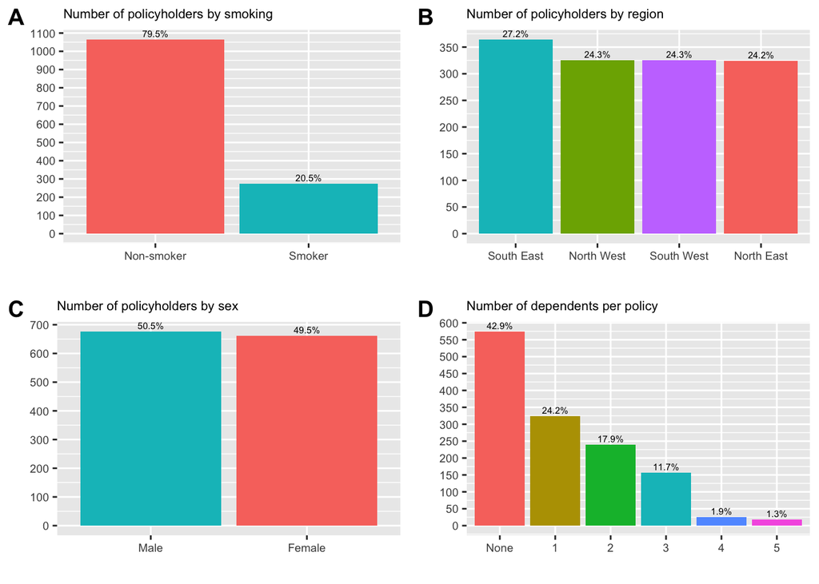

```r
figsize <- options(repr.plot.width=6, repr.plot.height=6) # set plot size for this plot

# Smoker count plot
smoker <- df %>%
    ggplot(aes(x=smoker, fill=smoker)) +
    geom_bar(show.legend = FALSE) +
    # add percentages on top of bars
    geom_text(
        stat='count',
        aes(label=paste0(round(after_stat(prop*100), digits=1), "%"),group=1),
        vjust=-0.4,
        size=2
    ) +
    # add labels
    labs(
        x = "",
        y = "",
        title = "Number of policyholders by smoking"
    ) +
    # rename x-ticks
    scale_x_discrete(
        labels = c("no" = "Non-smoker", "yes" = "Smoker")
    ) +
    # adjust y-ticks
    scale_y_continuous(
        breaks=seq(0,2000,100)
    ) +
    # resize text
    theme(
        plot.title = element_text(size=8),
        axis.text.x = element_text(size=7),
        axis.text.y = element_text(size=7)
    )

# Region count plot
region <- df %>%
    ggplot(aes(x=forcats::fct_infreq(region), fill=region)) +
    geom_bar(show.legend = FALSE) +
    # add percentages on top of bars
    geom_text(
        stat='count',
        aes(label = paste0(round(after_stat(prop*100), digits=1), "%"), group=1),
        vjust=-0.4,
        size=2
    ) +
    # add labels
    labs(
        x = "",
        y = "",
        title = "Number of policyholders by region"
    ) +
    # rename x-ticks
    scale_x_discrete(
        labels = c("northeast" = "North East", "northwest" = "North West",
                   "southeast" = "South East", "southwest" = "South West")
    ) +
    # adjust ticks
    scale_y_continuous(
        breaks=seq(0,350,50)
    ) +
    # resize text
    theme(
        plot.title = element_text(size=8),
        axis.text.x = element_text(size=7),
        axis.text.y = element_text(size=7)
    )

# Sex count plot
sex <- df %>%
    ggplot(aes(x=forcats::fct_infreq(sex), fill=sex)) +
    geom_bar(show.legend = FALSE) +
    # add percentages on top of bars
    geom_text(
        stat='count',
        aes(
            label=paste0(round(after_stat(prop*100), digits=1), "%"), group=1),
        vjust=-0.4,
        size=2
    ) +
    # add labels
    labs(
        x = "",
        y = "",
        title = "Number of policyholders by sex",
        fill = "Sex"
    ) +
    # rename x-ticks
    scale_x_discrete(
        labels = c("male" = "Male", "female" = "Female")
    ) +
    # adjust y-ticks
    scale_y_continuous(
        breaks=seq(0,700,100)
    ) +
    # resize text
    theme(
        plot.title = element_text(size=8),
        axis.text.x = element_text(size=7),
        axis.text.y = element_text(size=7)
    )

# Children count plot
children <- df %>%
    ggplot(aes(x=forcats::fct_infreq(children), fill=children)) +
    geom_bar(show.legend = FALSE) +
    # add percentages
    geom_text(
        stat='count',
        aes(label=paste0(round(after_stat(prop*100), digits=1), "%"), group=1),
        vjust=-0.4,
        size=2
    ) +
    # add labels
    labs(
        x = "",
        y = "",
        title = "Number of dependents per policy"
    ) +
    # rename x-ticks
    scale_x_discrete(
        labels = c("0" = "None")
    ) +
    # adjust y-ticks
    scale_y_continuous(
        breaks=seq(0,600,50)
    ) +
    # resize text
    theme(
        plot.title = element_text(size=8),
        axis.text.x = element_text(size=7),
        axis.text.y = element_text(size=7)
    )

# Plot grid
cowplot::plot_grid(
  smoker, region, sex, children,
  labels="AUTO",
  ncol = 2,
  nrow = 2
    )
```

### 5.0.2 Summary

- **Smoking status:** There are many more non-smokers (**80%**) than smokers (**20%**).
- **Region of residence:** Policyholders are evenly distributed across regions with South East being the most populous one (**27%**) with the rest of regions containing around 24% of policyholders each.
- **Sex:** There are slightly more men (**51%**) than there are women (**49%**) in the sample.
- **Dependents:** Most policyholders (**43%**) do not have dependents covered in their policy. For those who do have dependents covered in their policy, most have one dependent (**24%**). Maximum number of dependents covered is five (**1%**).

## 5.1 Correlations

```r
new_df <- df
new_df$sex <- ifelse(new_df$sex=="female", 0, 1)
new_df$smoker <- ifelse(new_df$smoker=="yes", 1, 0)
new_df$children <- as.numeric(new_df$children)
```

```r
new_df <- new_df[,-6]
res <- cor(new_df)
round(res, 2)
```

```
##            age   sex  bmi children smoker charges
## age       1.00 -0.02 0.11     0.04  -0.03    0.30
## sex      -0.02  1.00 0.05     0.02   0.08    0.06
## bmi       0.11  0.05 1.00     0.01   0.00    0.20
## children  0.04  0.02 0.01     1.00   0.01    0.07
## smoker   -0.03  0.08 0.00     0.01   1.00    0.79
## charges   0.30  0.06 0.20     0.07   0.79    1.00
```

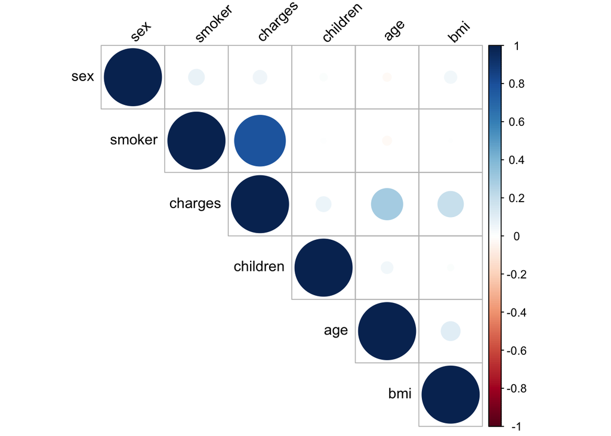

```r
corrplot(res, type = "upper", order = "hclust",
         tl.col = "black", tl.srt = 45)
```

There is not a strong correlation between variables overall. A strong correlation is found between **Smoker** and **Charges**. Even **Charges** and **Age** semes sto be **Weakly Correlated**.

## 5.2 Age Distribution

Let’s check for normality of **Age Variable** with a **Shapiro-Wilk Test for Normality**. This is a powerful Test for Normality, in particular for small samples.

- Null Hypothesis in this case is that the Distribution is Normal

```r
shapiro.test(df$age)
```

```
##
##  Shapiro-Wilk normality test
##
## data:  df$age
## W = 0.9447, p-value < 0.00000000000000022
```

With a **p-value** smaller than **alpha=0.05** we reject this hypothesis and assume that the variable is not normally distributed.

Check for Age Distribution.

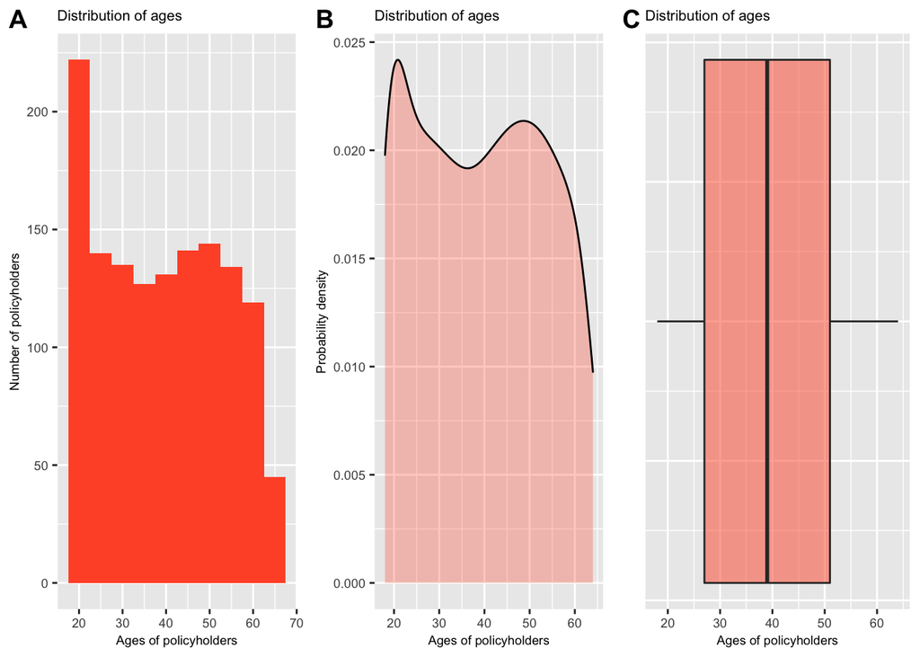

```r
# Age distribution
age_hist <- df %>%
    ggplot(aes(x=age))+
    geom_histogram(
        binwidth = 5,
        show.legend = FALSE,
        fill="#ff5733"
    )+
    labs(
        x = "Ages of policyholders",
        y = "Number of policyholders",
        title = "Distribution of ages"
    )+
    # resize text
    theme(
        plot.title = element_text(size=8),
        axis.text = element_text(size=7),
        axis.title = element_text(size=7)
    )

age_dens <- df %>%
    ggplot(aes(x=age)) +
     geom_density(
        alpha=.3,
        fill="#ff5733"
    )+
    labs(
        x = "Ages of policyholders",
        y = "Probability density",
        title = "Distribution of ages"
    )+
    # resize text
    theme(
        plot.title = element_text(size=8),
        axis.text = element_text(size=7),
        axis.title = element_text(size=7)
    )

age_box <- df %>%
    ggplot(aes(y=age)) +
    geom_boxplot(
        alpha=.5,
        fill="#ff5733"
    )+
    coord_flip() +
    theme(
        axis.text.y = element_blank(),
        axis.ticks.y = element_blank()
    )+
    labs(
        y = "Ages of policyholders",
        x = "",
        title = "Distribution of ages"
    )+
    # resize text
    theme(
        plot.title = element_text(size=8),
        axis.text = element_text(size=7),
        axis.title = element_text(size=7)
    )

cowplot::plot_grid(
    age_hist, age_dens, age_box,
    labels="AUTO",
    ncol = 3,
    nrow = 1
    )
```

### 5.2.1 Findings

Youngest policyholder is **18** and the eldest is **64**. All ages in the range are represented fairly equally apart from the youngest and eldest policyholders. **18-23 year olds** are the most populous group (among all 5-year segments) and **60-64 year olds** are the least represented 5-year age group. There are no outliers.

## 5.3 BMI Distribution

Check for **Body Mass Index** Distribution.

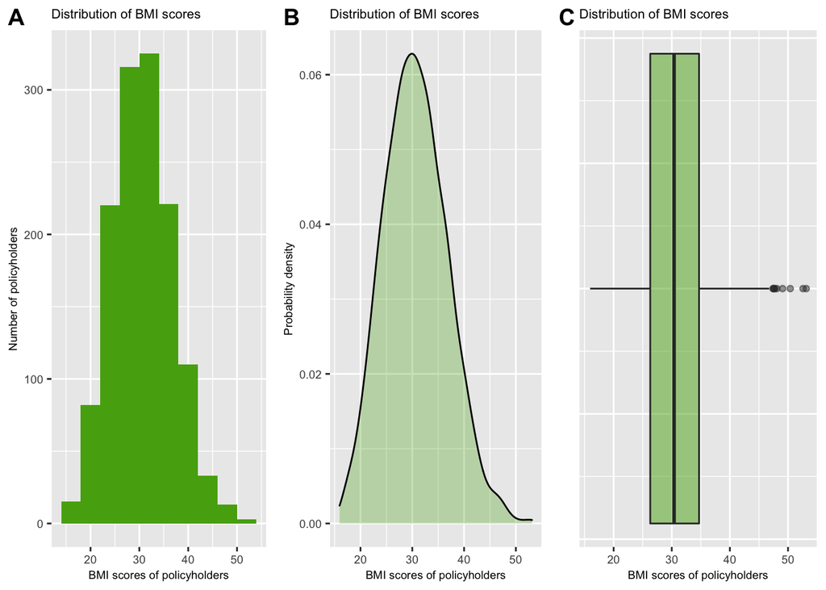

```r
# BMI distribution
bmi_hist <- df %>%
    ggplot(aes(x=bmi))+
    geom_histogram(
        binwidth = 4,
        show.legend = FALSE,
        fill = "#55ab11"
    )+
    labs(
        x = "BMI scores of policyholders",
        y = "Number of policyholders",
        title = "Distribution of BMI scores"
    )+
    # resize text
    theme(
        plot.title = element_text(size=8),
        axis.text = element_text(size=7),
        axis.title = element_text(size=7)
    )

bmi_dens <- df %>%
    ggplot(aes(x=bmi)) +
     geom_density(
        alpha=.3,
        fill="#55ab11"
    )+
    labs(
        x = "BMI scores of policyholders",
        y = "Probability density",
        title = "Distribution of BMI scores"
    )+
    # resize text
    theme(
        plot.title = element_text(size=8),
        axis.text = element_text(size=7),
        axis.title = element_text(size=7)
    )

bmi_box <- df %>%
    ggplot(aes(y=bmi)) +
    geom_boxplot(
        alpha=.5,
        fill="#55ab11"
    )+
    coord_flip() +
    theme(
        axis.text.y = element_blank(),
        axis.ticks.y = element_blank()
    )+
    labs(
        y = "BMI scores of policyholders",
        x = "",
        title = "Distribution of BMI scores"
    )+
    # resize text
    theme(
        plot.title = element_text(size=8),
        axis.text = element_text(size=7),
        axis.title = element_text(size=7)
    )

cowplot::plot_grid(
    bmi_hist, bmi_dens, bmi_box,
    labels="AUTO",
    ncol = 3,
    nrow = 1
    )
```

This seems to be Normally Distributed. Let’s check with a **Shapiro-Wilk Test**:

```r
shapiro.test(df$bmi)
```

```
##
##  Shapiro-Wilk normality test
##
## data:  df$bmi
## W = 0.99389, p-value = 0.00002605
```

### 5.3.1 Findings

BMI is not normally distributed even if **Median and Mean** being almost identical. There are a few outliers on the larger side. Minimum recorded **BMI score** is **16** and Maximum is **53.1**.

## 5.4 Charges Distribution

Check for **Charges** Distribution.

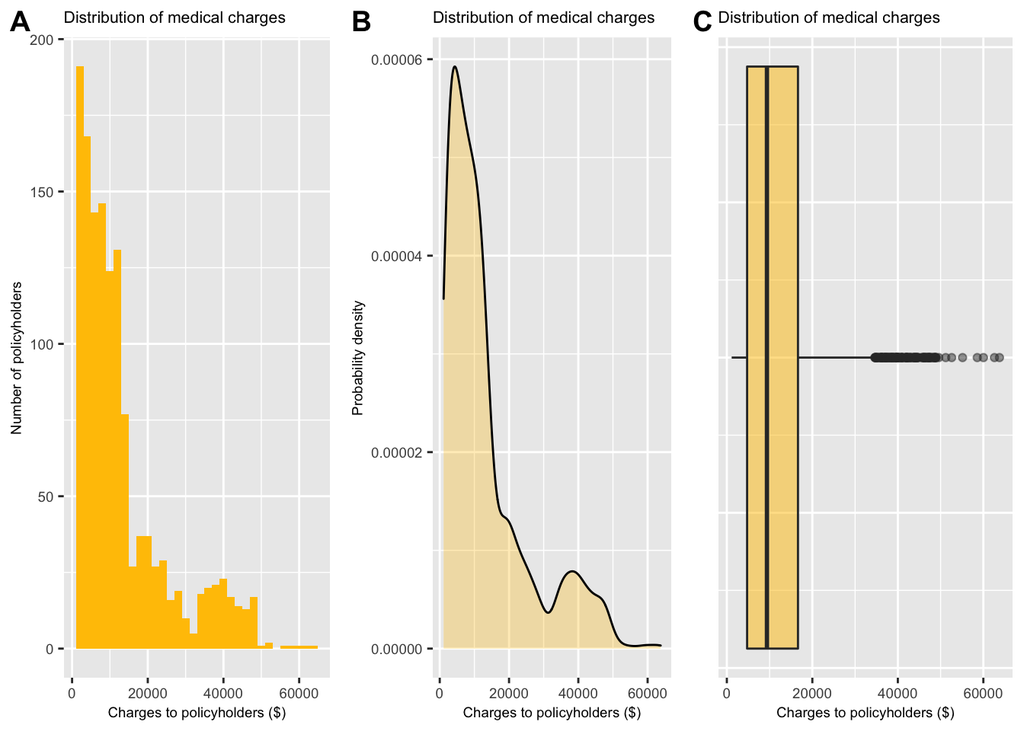

```r
# Charges distribution
charges_hist <- df %>%
    ggplot(aes(x=charges)) +
    geom_histogram(
        binwidth = 2000,
        show.legend = FALSE,
        fill = "#FFC300"
    )+
    labs(
        x = "Charges to policyholders ($)",
        y = "Number of policyholders",
        title = "Distribution of medical charges"
    )+
    # resize text
    theme(
        plot.title = element_text(size=8),
        axis.text = element_text(size=7),
        axis.title = element_text(size=7)
    )

charges_dens <- df %>%
    ggplot(
        aes(x=charges)
    ) +
     geom_density(
        alpha=.3,
        fill="#FFC300"
    ) +
    labs(
        x = "Charges to policyholders ($)",
        y = "Probability density",
        title = "Distribution of medical charges"
    ) +
    # resize text
    theme(
        plot.title = element_text(size=8),
        axis.text = element_text(size=7),
        axis.title = element_text(size=7)
    )

charges_box <- df %>%
    ggplot(aes(y=charges))+
    geom_boxplot(
        alpha=.5,
        fill="#FFC300"
    )+
    coord_flip()+
    # remove ticks from y-axis
    theme(
        axis.text.y = element_blank(),
        axis.ticks.y = element_blank()
    )+
    labs(
        y = "Charges to policyholders ($)",
        x = "",
        title = "Distribution of medical charges"
    )+
    # resize text
    theme(
        plot.title = element_text(size=8),
        axis.text = element_text(size=7),
        axis.title = element_text(size=7)
    )

cowplot::plot_grid(
    charges_hist, charges_dens, charges_box,
    labels="AUTO",
    ncol = 3,
    nrow = 1
    )
```

### 5.4.2 Findings

Charges are **Heavily Right-Skewed** with many outliers on the larger side. This means most charges are fairly low with a few particularly high charges. Smallest charge is **$1,122** and largest charge is **$63,770**.

## 5.5 Find Patterns

Check for Patterns in the structure of Data.

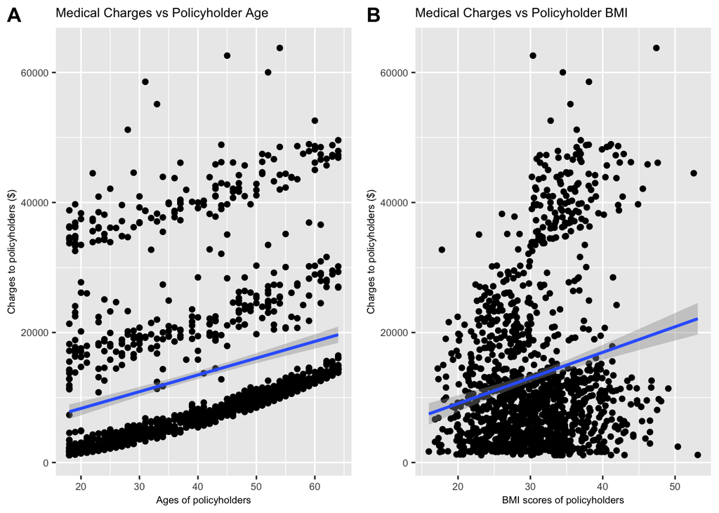

```r
age_scatter <- df %>%
    ggplot(aes(x=age, y=charges)) +
    geom_point()+
    # add a linear regression line
    geom_smooth(method='lm')+
    labs(
        x = "Ages of policyholders",
        y = "Charges to policyholders ($)",
        title = "Medical Charges vs Policyholder Age"
    )+
    # resize text
    theme(
        plot.title = element_text(size=9),
        axis.text = element_text(size=7),
        axis.title = element_text(size=7)
    )

bmi_scatter <- df %>%
    ggplot(aes(x=bmi, y=charges)) +
    geom_point()+
    # add a linear regression line
    geom_smooth(method='lm')+
    labs(
        x = "BMI scores of policyholders",
        y = "Charges to policyholders ($)",
        title = "Medical Charges vs Policyholder BMI"
    )+
    # resize text
    theme(
        plot.title = element_text(size=9),
        axis.text = element_text(size=7),
        axis.title = element_text(size=7)
    )

cowplot::plot_grid(
  age_scatter, bmi_scatter,
  labels="AUTO",
  ncol = 2,
  nrow = 1
    )
```

```r
options(figsize)
```

- **Medical Charges vs Policyholder Age:** There are interesting patterns here, showing three groups. The lower band shows a very **Strong Relationship** between **Medical Charges** and **Age**, with two other bands showing a less strong relationship. The general trend is a **Positive Correlation**, meaning as age increases, so do medical expenses.
- **Medical Charges vs Policyholder BMI:** There is a **Positive Relationship** between **BMI** and **Medical Expenses**, meaning people with higher BMI scores have higher medical bills. The relationship is not, however, very strong. There are possibly two groups to the scatter plot, judging by the spread of points above and below the regression line.

## 5.6 Relationships By Gender

Check in deep for Relationships by **Gender**, grouped by color (Red=**Female**, Blue=**Male**).

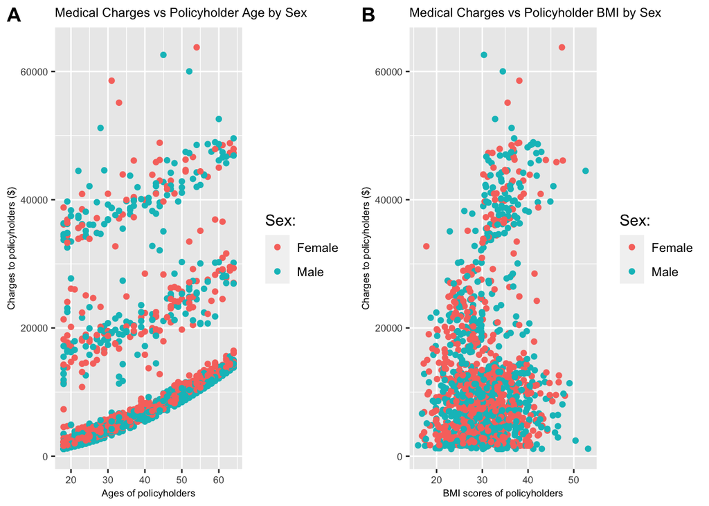

```r
# by sex
age_scatter_sex <- df %>%
    ggplot(aes(x=age, y=charges, color=sex)) +
    geom_point()+
    labs(
        x = "Ages of policyholders",
        y = "Charges to policyholders ($)",
        title = "Medical Charges vs Policyholder Age by Sex",
        color = "Sex:"
    )+
    scale_color_hue(labels = c("male" = "Male", "female" = "Female"))+
    guides(fill=FALSE)+
    # resize text
    theme(
        plot.title = element_text(size=9),
        axis.text = element_text(size=7),
        axis.title = element_text(size=7)
    )
bmi_scatter_sex <- df %>%
    ggplot(aes(x=bmi, y=charges, color=sex)) +
    geom_point()+
    labs(
        x = "BMI scores of policyholders",
        y = "Charges to policyholders ($)",
        title = "Medical Charges vs Policyholder BMI by Sex",
        color = "Sex:"
    )+
    scale_color_hue(labels = c("male" = "Male", "female" = "Female"))+
    guides(fill=FALSE)+
    # resize text
    theme(
        plot.title = element_text(size=9),
        axis.text = element_text(size=7),
        axis.title = element_text(size=7)
    )
cowplot::plot_grid(
    age_scatter_sex, bmi_scatter_sex,
    labels="AUTO",
    ncol = 2,
    nrow = 1
    )
```

Percentage of **Female** and **Male** genders seems to be **homogeneus**.

## 5.8 Relationships By Smoker Status

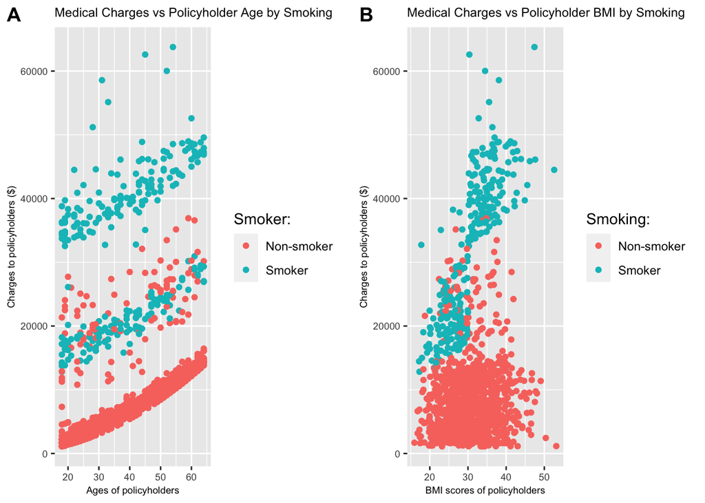

```r
#by smoker
age_scatter_smoker <- df %>%
    ggplot(aes(x=age, y=charges, color=smoker)) +
    geom_point()+
    labs(
        x = "Ages of policyholders",
        y = "Charges to policyholders ($)",
        title = "Medical Charges vs Policyholder Age by Smoking",
        color = "Smoker:"
    )+
    scale_color_hue(labels = c("no" = "Non-smoker", "yes" = "Smoker"))+
    guides(fill=FALSE)+
    # resize text
    theme(
        plot.title = element_text(size=9),
        axis.text = element_text(size=7),
        axis.title = element_text(size=7)
    )
bmi_scatter_smoker <- df %>%
    ggplot(aes(x=bmi, y=charges, color=smoker)) +
    geom_point()+
    labs(
        x = "BMI scores of policyholders",
        y = "Charges to policyholders ($)",
        title = "Medical Charges vs Policyholder BMI by Smoking",
        color = "Smoking:"
    )+
    scale_color_hue(labels = c("no" = "Non-smoker", "yes" = "Smoker"))+
    guides(fill=FALSE)+
    # resize text
    theme(
        plot.title = element_text(size=9),
        axis.text = element_text(size=7),
        axis.title = element_text(size=7)
    )
cowplot::plot_grid(
    age_scatter_smoker, bmi_scatter_smoker,
    labels="AUTO",
    ncol = 2,
    nrow = 1
    )
```

Instead, a very clear pattern emerges looking at **Smokers Plots**. There are groups in these two scatter plots, according to the smoking status of the policyholder. The ones with **Higher Medical Charges** are the **Smokers**, while the group of **Lower Medical Charges** is made of **Non-Smokers**.

# 6 Hypothesis Testing

## 6.1 Testing on Smokers Groups

**Exploratory Data Analysis** has indicated that smoking has an effect on charges.

```r
df %>%
    group_by(smoker) %>%
      summarise(
        count = n(),
        min = min(charges),
        median = median(charges),
        max = max(charges),
        IQR = IQR(charges)
      ) %>%
    arrange(desc(median)) # sort by median in descending order
```

```
## # A tibble: 2 × 6
##   smoker count    min median    max    IQR
##   <fct>  <int>  <dbl>  <dbl>  <dbl>  <dbl>
## 1 yes      274 12829. 34456. 63770. 20193.
## 2 no      1064  1122.  7345. 36911.  7376.
```

Clearly visible also from this table. There are differences in **Min**, **Median** and **Max**.

### 6.1.1 2-group Mann-Whitney U Test

An independent *2-group Mann-Whitney U Test* was performed to determine if this **difference is statistically significant**.

Assumptions of the test are as follows:

- Dependent variable is **Continuous**.
- Two independent **Categorical Variables** are present.
- There is **No Relationship** between the observations in each group of the independent variables or between the groups themselves.
- The **Shape of Distributions** of the independent variables must be known.

```r
wilcox.test(df$charges ~ df$smoker)
```

```
##
##  Wilcoxon rank sum test with continuity correction
##
## data:  df$charges by df$smoker
## W = 7403, p-value < 0.00000000000000022
## alternative hypothesis: true location shift is not equal to 0
```

- **H0:** There is no difference in the distribution scores.
- **HA:** There is a difference in the distribution scores.

The test indicated that there is a **Significant Difference** between the groups, **W = 7403, p < 0.001**. The **Null Hypothesis** is **Rejected**.

## 6.2 Testing on Region Groups

Check for differences in Medical Charges between **Region**.

```r
df %>%
    group_by(region) %>%
      summarise(
        count = n(),
        min = min(charges),
        median = median(charges),
        max = max(charges),
        IQR = IQR(charges)
      )
```

```
## # A tibble: 4 × 6
##   region    count   min median    max    IQR
##   <fct>     <int> <dbl>  <dbl>  <dbl>  <dbl>
## 1 northeast   324 1695. 10058. 58571. 11493.
## 2 northwest   325 1621.  8966. 60021.  9992.
## 3 southeast   364 1122.  9294. 63770. 15085.
## 4 southwest   325 1242.  8799. 52591.  8711.
```

There was also some difference in medical charges between regions.

### 6.2.1 Kruskal-Wallis Test

North East sees the largest charges **$10058**, followed by South East **$9294**, then by North West **$8966**, with South West **$8799** sees the smallest charges.

**Kruskal-Wallis Test** was performed to determine if these differences are significant.

Assumptions of the test are as follows:

- **Dependent Variable** is continuous.
- Two Independent **Categorical Variables** are present.
- There is **No Relationship** between the observations in each group of the independent variables or between the groups themselves.

All assumptions are met.

```r
kruskal.test(charges ~ region, data = df)
```

```
##
##  Kruskal-Wallis rank sum test
##
## data:  charges by region
## Kruskal-Wallis chi-squared = 4.7342, df = 3, p-value = 0.1923
```

- **H0:** There is no difference between the medians.
- **HA:** There is a difference between the medians.

The test showed that the difference between the median medical charges in different regions is **Not Significant** with an high p-value, **p = 0.19**. A significant level of 0.19 indicates a **19% Risk** of concluding that a difference exists when there is no actual difference.

The null hypothesis is **Accepted**.

## 6.3 Testing on Children Groups

Check for differences in **Medical Charges** between **Children Groups**.

```r
df %>%
    group_by(children) %>%
      summarise(
        count = n(),
        min = min(charges),
        mean = mean(charges),
        max = max(charges),
        IQR = IQR(charges)
      )
```

```
## # A tibble: 6 × 6
##   children count   min   mean    max    IQR
##   <fct>    <int> <dbl>  <dbl>  <dbl>  <dbl>
## 1 0          574 1122. 12366. 63770. 11706.
## 2 1          324 1711. 12731. 58571. 10840.
## 3 2          240 2304. 15074. 49578. 14094.
## 4 3          157 3443. 15355. 60021. 12547.
## 5 4           25 4505. 13851. 40182.  9616.
## 6 5           18 4688.  8786. 19023.  4145.
```

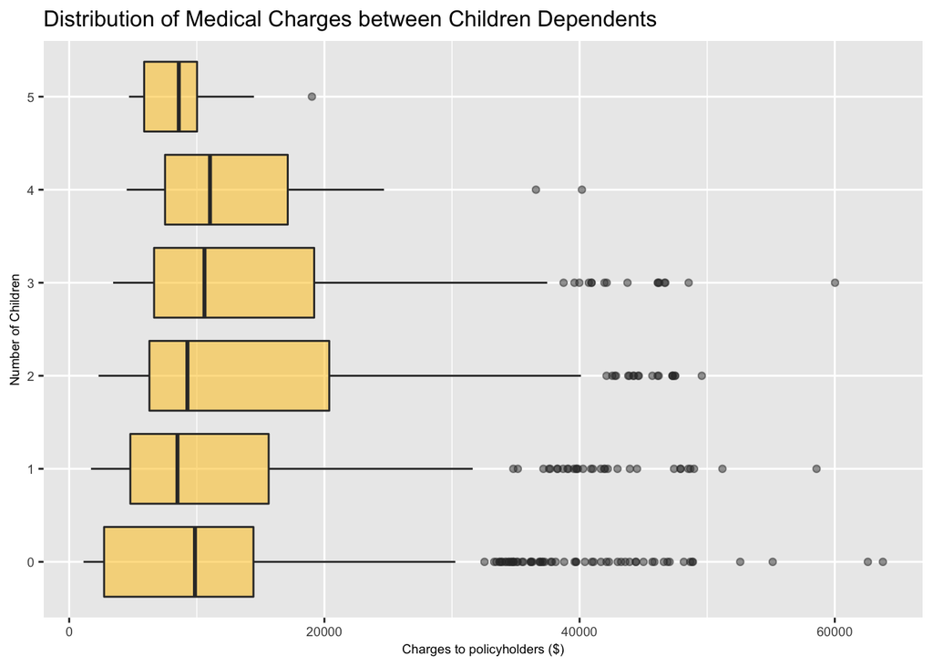

```r
charges_box_dff <- df %>%
    ggplot(aes(x=children, y=charges))+
    geom_boxplot(
        alpha=.5,
        fill="#FFC300"
    )+
    coord_flip()+
    labs(
        y = "Charges to policyholders ($)",
        x = "Number of Children",
        title = "Distribution of Medical Charges between Children Dependents"
    )+
    # resize text
    theme(
        plot.title = element_text(size=12),
        axis.text = element_text(size=7),
        axis.title = element_text(size=7)
    )

charges_box_dff
```

There are a lot of **Outliers** in “0”, “1”, “2” and “3” groups, the **mean** could be affected while the **median** is not sensitive to them.

### 6.3.1 Analysis of Variance (ANOVA)

For a comparison of **more than Two Group Means** the One-Way **Analysis of Variance** (ANOVA) is the appropriate method instead of the **t Test**.

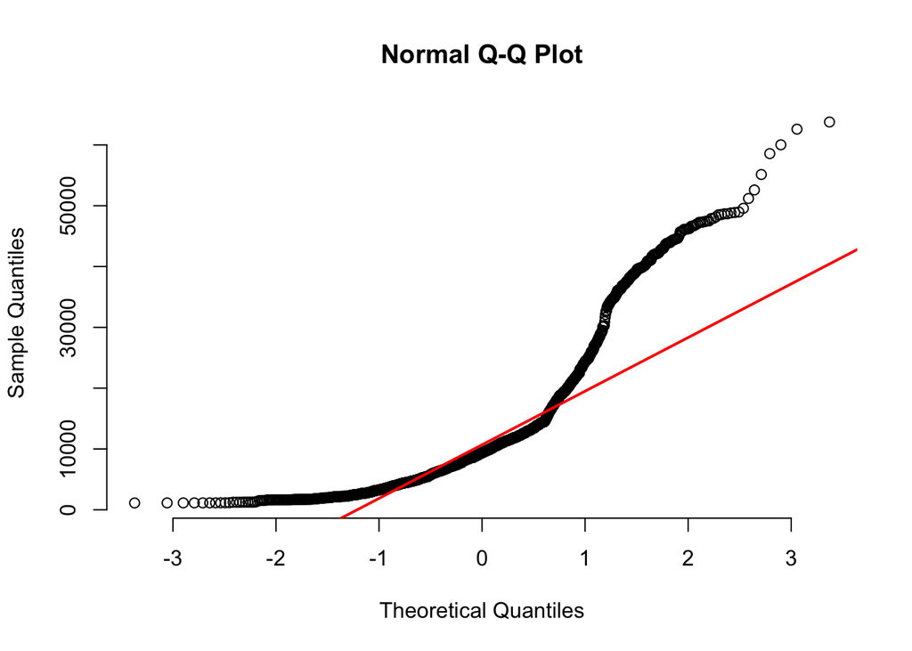

```r
qqnorm(df$charges, pch = 1, frame = FALSE)
qqline(df$charges, col = "red", lwd = 2)
```

In order to proceed with ANOVA, the variables must be **Normally Distributed**. Before we denoted the Non-Normality of these variables, so we proceeded with a **Normalization of Data** in order to make them suitable for **ANOVA**.

- **Log-Transformation**

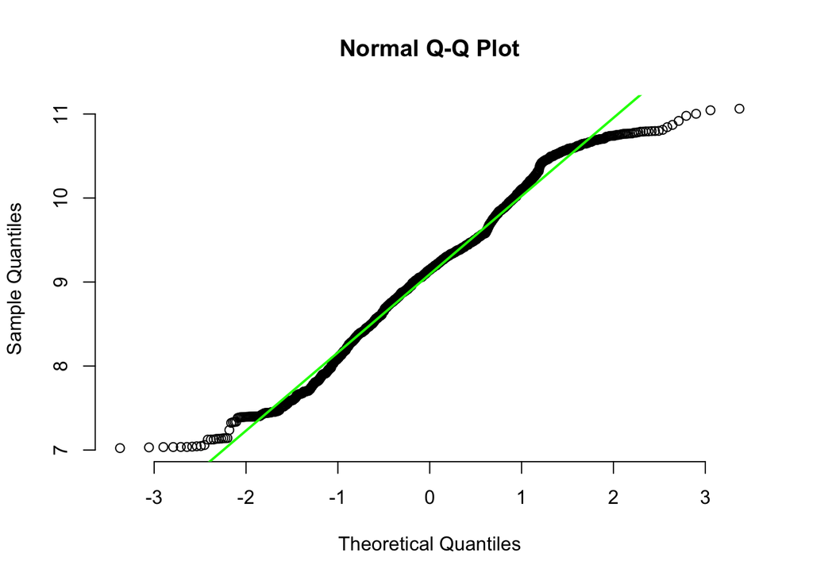

```r
norm_charges = log(df$charges)
qqnorm(norm_charges, pch = 1, frame = FALSE)
qqline(norm_charges, col = "green", lwd = 2)
```

In base R form, it produces an **ANOVA** table which includes an **F-test**. This so-called omnibus test tells you whether there are any differences in the comparison of means of the included groups.

```r
fit = aov(norm_charges ~ df$children)
summary(fit)
```

```
##               Df Sum Sq Mean Sq F value        Pr(>F)
## df$children    5   38.2   7.648   9.327 0.00000000957 ***
## Residuals   1332 1092.2   0.820
## ---
## Signif. codes:  0 '***' 0.001 '**' 0.01 '*' 0.05 '.' 0.1 ' ' 1
```

```r
library(broom)
aov(norm_charges ~ df$children, data = df) %>%
tidy()
```

```
## # A tibble: 2 × 6
##   term           df  sumsq meansq statistic  p.value
##   <chr>       <dbl>  <dbl>  <dbl>     <dbl>    <dbl>
## 1 df$children     5   38.2  7.65       9.33  9.57e-9
## 2 Residuals    1332 1092.   0.820     NA    NA
```

With a small **p-value** of over a **Significance Level** of **0.001** the Hypothesis of No Difference between groups is **Rejected**. Meaning differences between other groups found to be **Significant**.

# 7 Linear Regression

Linear regression analysis is used to predict the value of a **Response Variable** based on the value of an **Indipendent Variable**.

This form of analysis **estimates the coefficients** of the linear equation, involving one or more independent variables that best predict the value of the **Dependent Variable**. Linear regression fits a straight line or surface that **minimizes** the discrepancies between predicted and actual output values. There are simple linear regression calculators that use a **Least Squares** method to discover the **best-fit line** for a set of paired data.

Response variable (charges) is to be transformed to reduce **skewness** and meet the assumption of **normality**.

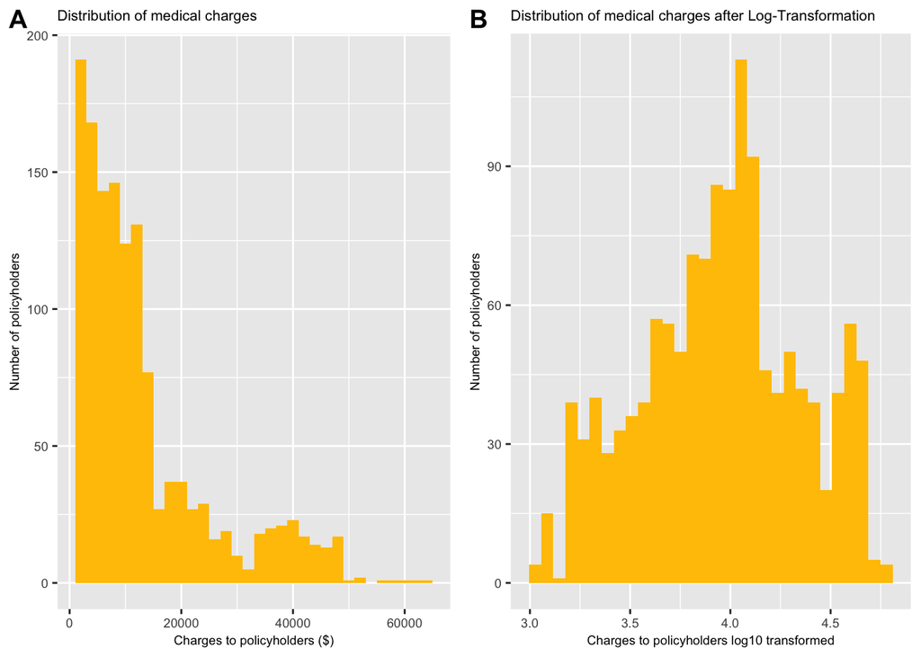

```r
charges_hist <- df %>%
    ggplot(
        aes(x=charges)
        ) +
    geom_histogram(
        binwidth = 2000,
        show.legend = FALSE,
        fill = "#FFC300"
        )+
    labs(
        x = "Charges to policyholders ($)",
        y = "Number of policyholders",
        title = "Distribution of medical charges"
        )+
    # resize text
    theme(
        plot.title = element_text(size=8),
        axis.text = element_text(size=7),
        axis.title = element_text(size=7)
    )

charges_hist_log10 <- df %>%
    ggplot(
        aes(x=log10(charges))
        ) +
    geom_histogram(
        show.legend = FALSE,
        fill = "#FFC300"
        )+
    labs(
        x = "Charges to policyholders log10 transformed",
        y = "Number of policyholders",
        title = "Distribution of medical charges after Log-Transformation"
        )+
    # resize text
    theme(
        plot.title = element_text(size=8),
        axis.text = element_text(size=7),
        axis.title = element_text(size=7)
    )

cowplot::plot_grid(
    charges_hist, charges_hist_log10,
    labels="AUTO",
    ncol = 2,
    nrow = 1
    )
```

```r
df$logCharges<- log10(df$charges)
```

```r
model <- lm(logCharges ~ smoker, data = df)

summary(model)
```

```
##
## Call:
## lm(formula = logCharges ~ smoker, data = df)
##
## Residuals:
##      Min       1Q   Median       3Q      Max
## -0.76674 -0.18978  0.05374  0.20779  0.75047
##
## Coefficients:
##             Estimate Std. Error t value            Pr(>|t|)
## (Intercept) 3.816681   0.009141  417.52 <0.0000000000000002 ***
## smokeryes   0.658337   0.020200   32.59 <0.0000000000000002 ***
## ---
## Signif. codes:  0 '***' 0.001 '**' 0.01 '*' 0.05 '.' 0.1 ' ' 1
##
## Residual standard error: 0.2982 on 1336 degrees of freedom
## Multiple R-squared:  0.4429, Adjusted R-squared:  0.4425
## F-statistic:  1062 on 1 and 1336 DF,  p-value: < 0.00000000000000022
```

The group of **Effective Smokers** is really significant for the **Linear Regression Model**.

The model explains **44.2%** of total variance in the sample.

# 8 Partial Correlation

Even **Age** is correlated with **Charges** variable, so let’s check for partial correlation finding residuals for **Charges-Age Linear Regression Model**.

```r
model2 <- lm(logCharges ~ age, data = df)

summary(model2)
```

```
##
## Call:
## lm(formula = logCharges ~ age, data = df)
##
## Residuals:
##     Min      1Q  Median      3Q     Max
## -0.5834 -0.1809 -0.1344  0.2172  0.9554
##
## Coefficients:
##              Estimate Std. Error t value            Pr(>|t|)
## (Intercept) 3.3632837  0.0275066  122.27 <0.0000000000000002 ***
## age         0.0150028  0.0006605   22.71 <0.0000000000000002 ***
## ---
## Signif. codes:  0 '***' 0.001 '**' 0.01 '*' 0.05 '.' 0.1 ' ' 1
##
## Residual standard error: 0.3393 on 1336 degrees of freedom
## Multiple R-squared:  0.2786, Adjusted R-squared:  0.2781
## F-statistic:   516 on 1 and 1336 DF,  p-value: < 0.00000000000000022
```

The model explains **27,8%** of total variance in the sample.

### 8.0.1 Residuals for First Model

```r
res1 <- model$residuals
head(res1)
```

```
##          1          2          3          4          5          6
## -0.2475188 -0.5797527 -0.1683734  0.5254351 -0.2293230 -0.2418834
```

### 8.0.2 Residuals for Second Model

```r
res2 <- model2$residuals
head(res2)
```

```
##          1          2          3          4          5          6
##  0.5791630 -0.3964052 -0.1350535  0.4837412 -0.2560141 -0.2535718
```

## 8.1 Correlation between Residuals

By computing the correlation between **Residuals of First Model** and **Residuals of Second Model** we obtain the **Partial Correlation**.

```r
cor(res1, res2)
```

```
## [1] 0.4254377
```

The most the value is closer to **0**, the more there is no **Important Relationship** between the **Two Models**.

# 9 Conclusions